# 基于字符级卷积神经网络的民宿顾客意见挖掘

### Homestay Customer Opinion Mining Based on Character-level Convolutional Neural Networks

姓 名：张振

指导老师：杨有 副教授

答辩时间：2019.6.02

所学专业：计算机技术

# 目录

### 1. 研究背景和意义

### 2. 顾客意见挖掘现状

### 3. 主要工作

### 4. 程序演示

### 5. 总结与展望

## PART 01 研究背景和意义

### 依托互联网经济的发展，民宿业坐上了互联网经济的“顺风车”，百度指数显示民宿指数已经高于酒店。民宿业准入门槛较低，繁荣的背后也有许多问题，比如：民宿刷单问题、民宿宰客问题等等。怎样更合理的对民宿进行监管，以实现民宿业生态的“自淘汰”，这些问题的解决都需要更深入的顾客意见挖掘作为支持。

[figure not shown]

## PART 02 顾客意见挖掘研究现状

### 目前基于意见挖掘应用的有：

### 1. 对电商平台对评论数据进行情感分析，提升产品质量

### 2. 帮助智能汽车运营平台实现对车载数据的用户画像，实现个性化推荐

### 3. 帮助对公众数据进行挖掘，实现舆情分析

### 本文以民宿用户生成数据为主，对民宿顾客意见进行挖掘。

## PART 03 主要工作

### 借助于自然语言处理技术进行数据挖掘，开展了基于携程民宿的数据采集、预处理、主题提取和情感分析相关工作，实现端对端的数据处理流程。

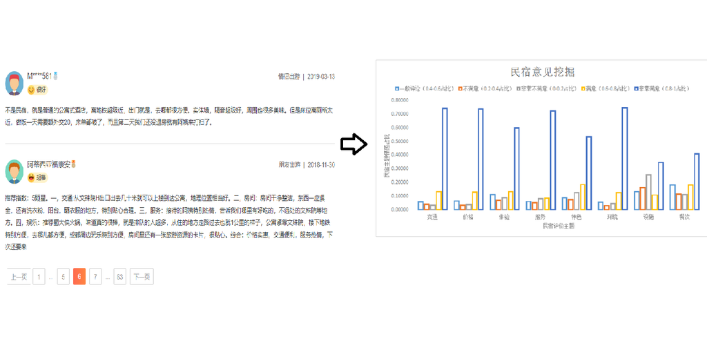

## PART 03 主要工作

### 流程设计

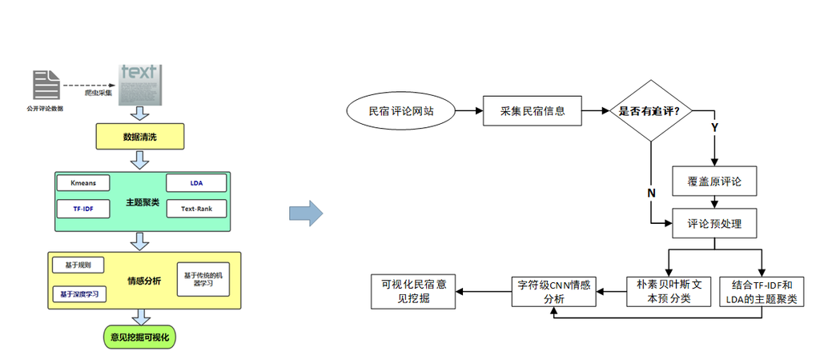

## PART 03 主要工作

### 数据采集

### 问题分析：原始的Scrayp不支持POST的请求形式，无法直接请求JSON格式，携程的网页结构较复杂，需要带有POST功能加入。

### 解决方法：使用Requests的POST的功能增加Scrapy框架的灵活性，利用Requests的POST功能搭配Scrapy的多线程的能力，开发出一套具有多线程、代理IP、自动清洗数据的网络爬虫工程。

## PART 03 主要工作

### 数据采集采集性能测试

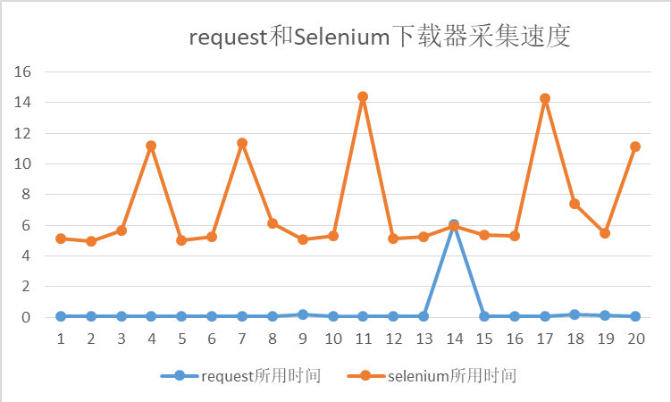

## PART 03 主要工作

### 评论预处理：基于词性标注的民宿评论截断处理

### 问题分析:原始的评论语料如：“环境很不错！餐饮也挺好的”是无法直接进行主题提取，因为原始的评论之中含有两个主题，“环境”和“餐饮”，需要评论截断。

### 解决方法：通过词性标注技术，识别句子中的标点符号，并以此对句子进行切分，如图所示。

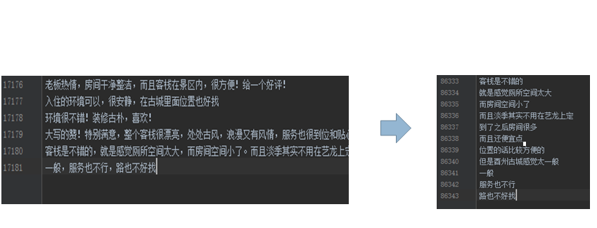

## PART 03 主要工作

### 主题提取：多向量化下的LDA的民宿主题提取

### 问题分析：原始的LDA主题聚类算法是依据词频的向量化方式进行的，容易造成停用词排在前面，从而造成提取的主题质量下降，无法挖掘隐含特征。

### 解决方法：采用的是TF-IDF的词向量化的方式来代替传统的词频向量化，TF-IDF不仅考虑到词频影响，而且结合逆文档频率可以使更多合理的词权重较大，有助于挖掘隐含特征，文本向量化如图所示。

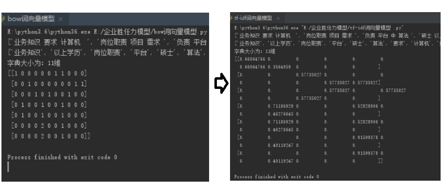

## PART 03 主要工作

### 主题提取流程设计：基于词性标注下的LDA的民宿主题提取流程

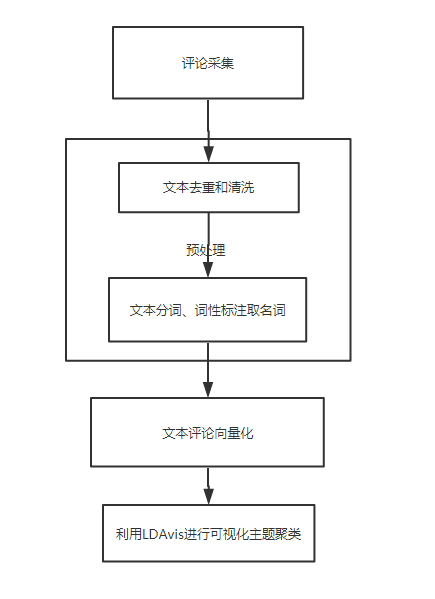

## PART 03 主要工作

### 主题提取过程：基于词性标注，结合TF-IDF和LDA的民宿主题属性词典构建，可视化主题提取，k=8时的主题聚类。

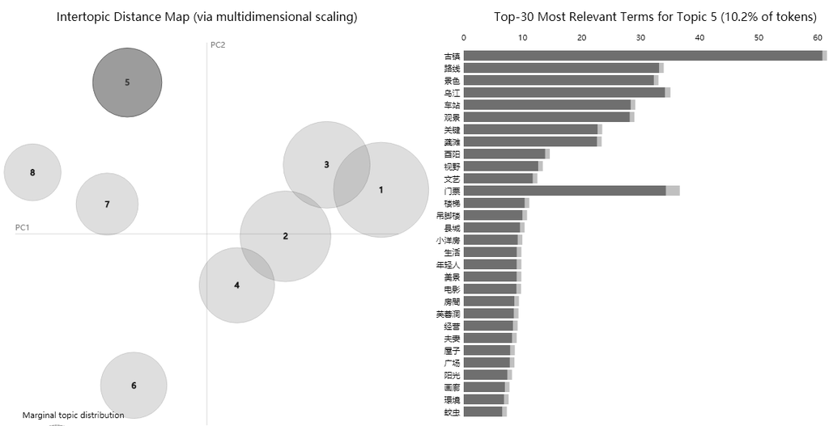

## PART 03 主要工作

### 主题提取结果：左边为民宿标准文件的参考主题，右边为主题挖掘扩充后的主题，如下所示。

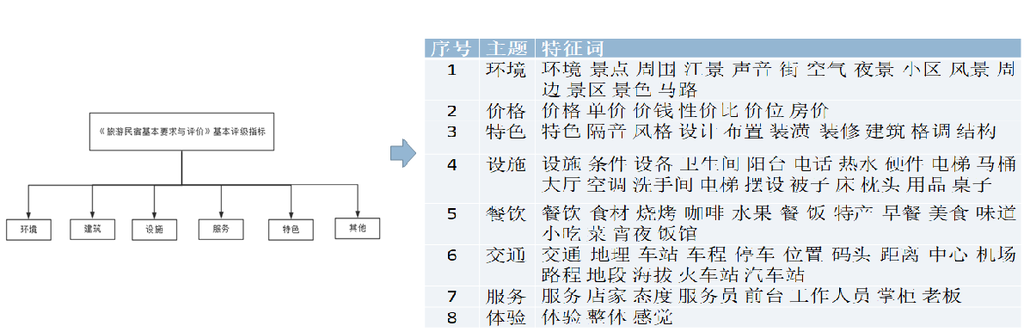

## PART 03 主要工作

### 情感分析数据集构建：用户打分和用户评论情感呈现强烈的正相关趋势，所以本文使用用户打分为1的作为消极，打分为5的作为积极，针对消极文本不平衡的问题，利用打分为2的切分后的评论，进行数据填充，并构建弱分类器，当朴素贝叶斯按照概率输出的时候，值域通常在[0，1]之间，通常一个类别的后验概率大于0.5即可分类成功，本文使用输出概率值大于0.9作为置信度高的积极文本，输出概率小于0.1的作为置信度高的消极文本，如下图的情感不一致。

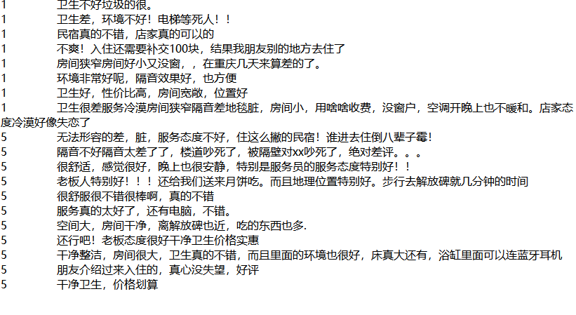

## PART 03 主要工作

### 情感的细粒度分析方法：在建立训练集的时候使用极端情感（用户打分的1分和5分），字符级卷积神经网络的下的积极情感下的Softmax概率输出映射为情感极性。

### 问题分析：评论分词由于用户字典覆盖不全的问题，容易造成分词误差，在使用中不同的分词器会有不同的效果，研究不分词的情况下进行模型训练。

### 解决方法：本文将字符级的文本当做原始信号，按照字符进行去重，并按照字符频率进行降序排列建立字符表，即{字符：索引ID}的形式，通过查询字符表中的的位置索引ID的方式将评论向量化，并且构建一维卷积核的卷积神经网络去进行特征提取，这种方式无需考虑语言的语法或语义结构，并且比词级的维度更低。

```python
# tensorflow代码运行
from SA import CnnModel
import tensorflow as tf
import os
# os.environ['TF_CPP_MIN_LOG_LEVEL'] = '2'
for i in open('data/data/1.txt', 'r', encoding='utf-8'):
    tf.reset_default_graph()
    test_text = i.strip().split('\t')[1]
    predict_score = CnnModel().emotion_score(test_text)
    print('{}-{}'.format(test_text,predict_score))
```

```
INFO:tensorflow:Restoring parameters from checkpoints/textcnn\best_validation
卫生不好-0.009347633458673954
INFO:tensorflow:Restoring parameters from checkpoints/textcnn\best_validation
店家服务差-0.046952810138463974
INFO:tensorflow:Restoring parameters from checkpoints/textcnn\best_validation
隔音不好-0.010467812418937683
INFO:tensorflow:Restoring parameters from checkpoints/textcnn\best_validation
房间很小-0.044162001460790634
INFO:tensorflow:Restoring parameters from checkpoints/textcnn\best_validation
有家的感觉-0.8834744095802307
INFO:tensorflow:Restoring parameters from checkpoints/textcnn\best_validation
位置繁华-0.788189172744751
INFO:tensorflow:Restoring parameters from checkpoints/textcnn\best_validation
交通便利-0.9982715845108032
```

## PART 03 主要工作

### 情感分析框架设计：本文字符级卷积神经网络情感分析框架

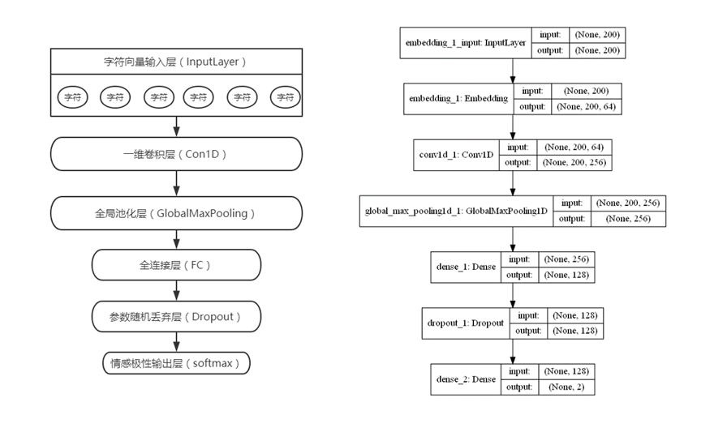

## PART 03 主要工作

### 情感分析的性能评测

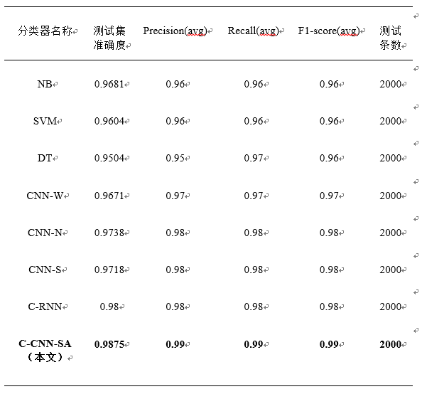

## PART 03 主要工作

### 情感分析结果：单一主题下的评论进行情感分析可视化后的结果。

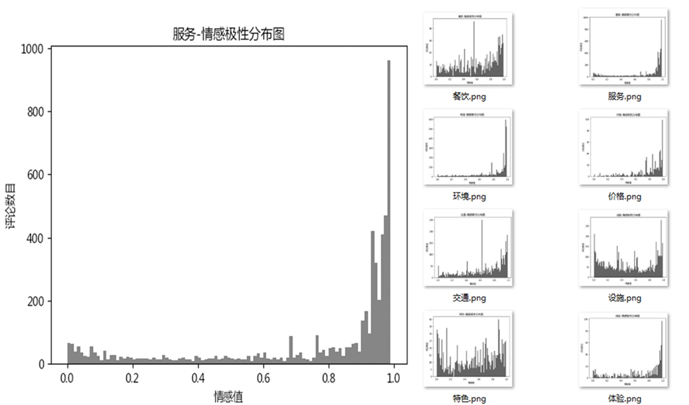

## PART 03 主要工作

### 意见挖掘可视化： 以0.2为间隔的细粒度的情感强度可视化。

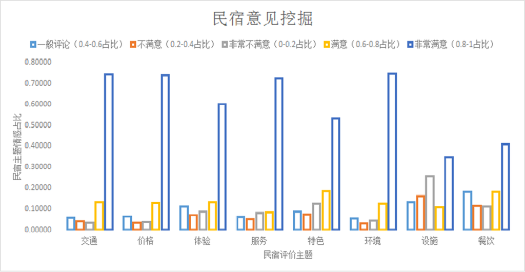

```python
# 程序演示
from IPython.display import HTML
HTML("""<video width="980" height="500" controls><source src="video/demo.mp4" type="video/mp4"></video>""")
```

[video not shown]

## PART 04 总结与展望

### 论文总结

### 本文对于民宿顾客意见挖掘的问题，开展了基于数据采集、预处理、主题提取和情感分析相关工作，包括：

### 1. 数据采集---结合Requests和Scrapy的联合数据采集

### 2. 评论预处理---基于词性标记的评论截断

### 3. 隐含主题提取---结合词性标注、TF-IDF和LDA主题提取

### 4. 数据集的构建问题---自动标注和弱监督预训练

### 5. 细粒度的情感分析问题---基于字符级卷积神经网络的情感分析

## PART 04 总结与展望

### 论文展望

### 不足之处：

### 1. 基于匹配的主体识别容易随着新词的产生容易造成覆盖率不全

### 2. 情感训练语料较为单一，场景泛化能力有待提升

### 后续工作：

### 1. 后续考虑使用基于模型的属性识别，增加主题识别的泛化性

### 2. 考虑使用迁移学习模型，增加情感分析场景的泛化性